# Practicum 2: Reproducible Research

Data Science for Biomedical Informatics (BMIN503/EPID600)

In this practicum, we will continue to use git/GitHub and become familiar with how to use R/RStudio. Completion of these steps is necessary for future coursework.

### Update a Repository

Last time, you created a GitHub account (if you didn’t already have one) and made repositories. Today, you will learn to update repositories. As you work on a project by updating code, data files, documentation, etc, you can save versions to GitHub. Additionally, as repositories are updated on GitHub by others, you can keep updating your local copies. This way, teams can keep track of the latest version of a project and go back to previous versions as necessary.

Go to the local repository folder, `test-repo`, you created last time.

```
cd [your-path]/test-repo
```

Now, create a new file titled [your last name].txt and add a line of text to it.

```
touch [your last name].txt
echo "This is my new file." > [your last name].txt
```

Assuming that this is a draft of your repo that you’d like to update, you will *commit* the changes locally, and then update the remote repo on GitHub. To let git know what new and modified existing files should be part of a repo, use the following:

```
git add .  #to add all new files
git add -u #updates tracking for all files that have changed
git add -A #both of these
```

Use the last command to add the new `[your last name].txt` file you created. To *commit* all changed files as the current state of a local repo, type:

```
git commit -m "[message about commit]"
```

Lastly, update the remote repository (GitHub in our case) by *pushing* the committed repo:

```
git push --set-upstream origin master
```

Note that you will likely have trouble with this step if you don’t have ssh keys set up. Once that long command has run once, you can use the shortened push version and the settings from the previous entry will apply:

```
git push
```

Go to your GitHub account online, and check to be sure that the new file is there. To update a repo locally to its latest remote version, which is required prior to you pushing updates, you *pull* the latest version:

```
git pull
```

Oftentimes, rather than work on the master branch, you may want to create a branch to test new things. One common choice is to have a *development* branch. If multiple people are working on different aspects of a project, each may want their own branch too. To create a new branch:

```
git checkout -b [branchname]
```

To see your current branch:

```
git branch
```

The main branch with the current version of the project is the *master* branch. To go to the master branch:

```
git checkout master
```

When you push your local repo, it will go to the branch you are currently working in. When the changes from a branch are ready to be part of the main repository, you *merge* branches. For example, to merge `[branchname]` into the active branch you are working on, use:

```
git merge [branchname]
```

Conflicts between branches have to be resolved for the merge to complete. In cases where you want to merge changes back into a GitHub branch/repo that belongs to someone else, you need to send a *pull request*. For example, if you were to update the `datasharing` repo you forked last time and wanted its author, jtleek, to include your changes, you would go to

https://github.com/jtleek/datasharing

and click on the “Pull Requests” on the right-hand menu bar under “Code” and “Issues.” Those are the basics of GitHub, but there are many other git/GitHub features you can learn about via resources such as these:

https://rogerdudler.github.io/git-guide/

http://kbroman.org/github_tutorial/

http://nvie.com/posts/a-successful-git-branching-model/

### RStudio

As discussed in class, RStudio is a free R user interface that makes development of code and integration of R files with reproducible research tools very straightforward. Open RStudio and explore its different windows. In the R Console, you can type and execute R commands. For example, try the commands in grey below (your output should be what appears in the white boxes):

```r
1+2
```

```
## [1] 3
```

```r
c(1:5)
```

```
## [1] 1 2 3 4 5
```

```r
cat("hello", "there")
```

```
## hello there
```

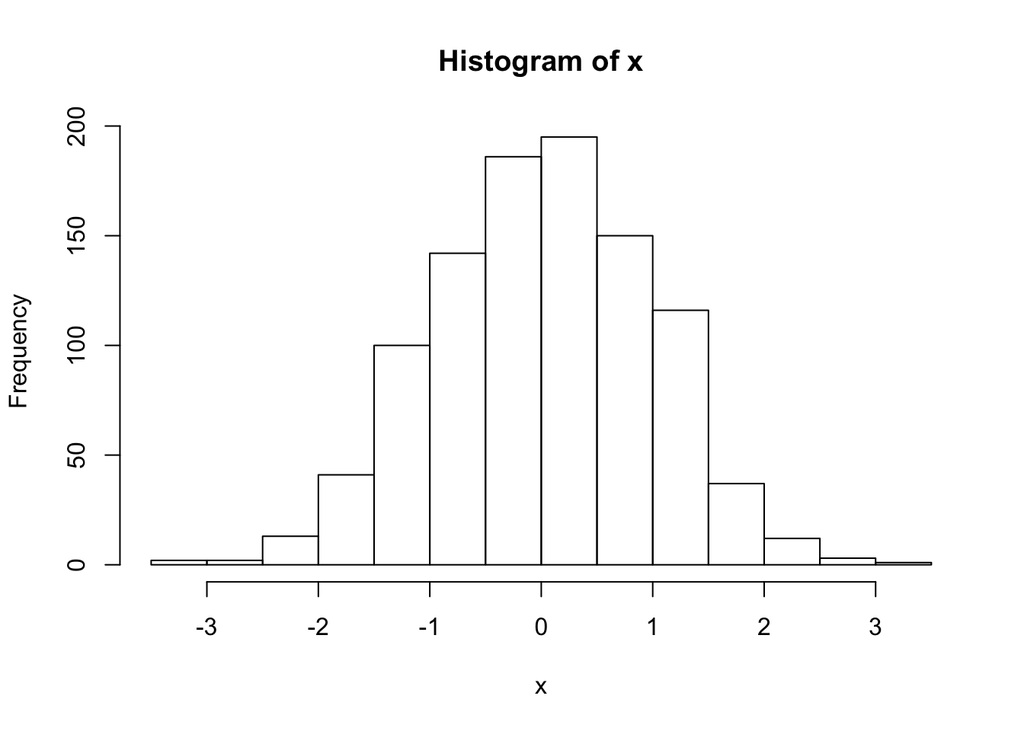

```r
x <- rnorm(1000)
hist(x)
```

We will discuss R commands in more detail later. Above the R console, you can edit files with R code. To the right, there are windows that provide R output, current settings, history, package installation, and R documentation.

### R Settings

Prior to working in R, there are some settings that you should become familiar with. The current *working directory*, where your data is read and saved to can be checked by typing the follwing at the console:

```r
getwd()
```

To see what files are in this current directory:

```r
dir()
```

To see what functions are loaded:

```r
ls()
```

To change directories, you can use `setwd()` within the command line or in an R script. Alternatively, you can change directories by browsing to one. In RStudio, go to Session -> Set Working Directory -> Choose Directory, then select a new directory.

### R Packages

As mentioned during the lecture, many of the R functions you will use are in packages, which have to be installed and loaded prior to use. From the R console, install these packages from CRAN:

```r
install.packages("knitr")
install.packages("rmarkdown")
install.packages("tidyverse")
```

In RStudio, packages can be installed interactively with the “Install Packages” tool. Once packages are installed, it is necessary to tell R about them each time you start an R session or include them within a script where they are used with the `library()` command:

```r
library(tidyverse)
```

To see loaded packages, use the `search()` funcion.

### Help in R

To get help about specific R functions, type `?` before the command. In RStudio, the effect of this will be to open the `Help` window with documentation for that specific command.

```r
?read.table
```

More broadly, when you don’t know the name of the command you are looking for, you can use the following command to do a text search through the R documentation:

```r
help.search("mean")
```

Recall that web searches often locate answers to problems encountered or can be used to look up functions. Use `sessionInfo()` when asking a question about R either by email or to a forum. This helps others understand the environment where a problem arises.

### R Scripts

Any text editor can be used to edit R files, including the one that is available via the R console. We will use RStudio to edit text files with R commands. *R script* files (.R ending) consist of R functions, comments, and variables. To create a new R script file, use the RStudio new document icon in the upper-left-hand corner and select “R Script”. In the new document, type the following:

```r
#Test R script
x<-1
y<-2
x+y
```

Now save the file as `test.R`. To execute the code, click on “Run” above the text editor window. Note that the single line where the cursor is located is run by default. You can select multiple lines of code and then click “Run” to execute more than one line. To run the entire document, you can select “Source” instead. Alternatively, you can load an R script into your R environment at the command line by typing:

```r
source("test.R")
```

Verify that the contents of `test.R` loaded properly by typing `x` and `y` at the command line. Now modify their values in the document and repeat the steps to see their values changed.

### R Markdown

For class, we will mostly use R Markdown files (.Rmd ending) since these are easily converted into visually appealing output documents that include text, graphics, and R code. Such documents are a great way to keep a “lab notebook” for data science projects. To create a new R Markdown file, use the RStudio new document icon in the upper-left-hand corner and select “R Markdown”. Give it a title and author of your choice (or leave the default options) and click “OK”. The new document has some sample text and commands that illustrate some of the main components of an R Markdown file. To save the R Markdown file, use File -> Save As, and then choose a `test.Rmd` and click “Save”. Click on the “Knit HTML” icon at the top of the file to generate an html document based on the template and compare the two. If you’d like, repeat this with PDF and Word options to see other output formats. For these latter two to work, you have to have additional software installed on your computer.

You can download an R Markdown [cheat sheet](https://www.rstudio.com/wp-content/uploads/2016/03/rmarkdown-cheatsheet-2.0.pdf), find one under Help->Cheatsheets menu of RStudio, and read more about it here: http://rmarkdown.rstudio.com. To see all of the settings possible with html documents, you can read this [guide](http://rmarkdown.rstudio.com/html_document_format.html).